# Document Classification Case Study: Kiva Loans

Dr. Stephen W. Thomas, Queen’s University

```r
knitr::opts_chunk$set(echo = TRUE, warning=FALSE, message=FALSE, fig.align='center')
```

[figure not shown]

```r
library(tidyverse)
library(scales)
library(rpart)
library(rpart.plot)
library(RColorBrewer)
library(MLmetrics)
library(topicmodels)
library(tidytext)
library(knitr)
library(rpart)
library(rpart.plot)
```

# Introduction

[Kiva Microfunds](https://www.kiva.org/) is a non-profit that allows people to lend money to low-income entrepreneurs and students around the world. Started in 2005, Kiva has crowd-funded millions of loans with a repayment rate of 98% to 99%.

Kiva includes both traditional demographic information, such as gender and location, as well as personal stories on each borrower because Kiva wants lenders to connect with the borrowers on a human level. An example:

*Evelyn is 40 years old and married with 3 kids. She is in the Karura Hope women group and her life has been changed by the first KIVA loan she received last year which she is completing this quarter. Before she received the loan, she used to sell 9 litres of milk daily to local residents. After receiving the loan she bought iron sheets, five cement packets, one lorry of sand, some ballast and animal feed for her cows and improved her cow shed. Today she sells a daily average of 40 litres of milk to the Kiamba Dairy cooperative society, which is affiliated to the Kenya Cooperative Creameries at a cost of USD 0.28 per litre. Her daily farming has really grown. Evelyn intends to buy another dairy cow and a tank of water for home consumption and for her cows. She intends to repay in monthly installments.*

Despite her uplifting story, and her previous successful loan, Evelyn defaulted on her next loan of 900 USD.

In this case study, we will explore past Kiva loans and build a prediction model (in particular, a decision tree classifier) to predict which future borrowers will pay back loans, and which will default. A key question we will explore is: does adding text (i.e., the personal stories) to the prediction model increase or decrease the model’s prediction power?

This case study will provide lots of data, tables, and graphs, but is intentionally light on commentary, analysis, and decision making. That’s your job!

## Case Discussion Questions

At the end of this case study, we will have a group discussion around the following questions:

1. Does text data help in predicting which loan seeker will default?
2. Which words are most biased towards defaulting? Is this expected/intuitive?
3. According to the decision tree prediction models, what variables best predict a default?
4. As a decision maker, would you recommend the use of textual data in your prediction models?
5. As a lender, what other information would you like to have?

# Kiva Background

The key concepts in the Kiva world are:

- **Loan**. A loan is the most important concept at Kiva. Most other concepts are in some way related to a loan.
- **Borrower**. A borrower is someone who has requested a loan. Borrowers are often referred to as *businesses* or *entrepreneurs* in order to emphasize the entrepreneurial spirit of these individuals who work to make a difference in their lives.
- **Lender**. A lender is a user registered on the Kiva website for the purposes of lending money and participating in the community. Some lenders have public profiles, known as lender pages, on the Kiva website, where they can share details about their activities and mission. Most lenders, however, refrain from displaying their public information and are referred to as “anonymous.”
- **Partner.** A partner, or Kiva field partner, is usually a microfinance institution with which Kiva works to find and fund loans. Every loan at Kiva is offered by a partner to a borrower, and the partner works with Kiva to get funding for that loan from lenders.

# Loading the Data

```r
df_full <- read_csv("kiva.csv")
```

```r
str(df_full)
```

[output not shown]

```r
df_full$id = 1:nrow(df_full)
df_full$status = as.factor(df_full$status)
df_full$sector = as.factor(df_full$sector)
df_full$country = as.factor(df_full$country)
df_full$gender = as.factor(df_full$gender)
df_full$nonpayment = as.factor(df_full$nonpayment)
```

Let’s look at a sample of our data.

```r
head(df_full, n=20)
```

```
## # A tibble: 20 × 8
##       status       sector
##       <fctr>       <fctr>
## 1  defaulted  Agriculture
## 2  defaulted         Food
## 3  defaulted         Food
## 4  defaulted     Services
## 5  defaulted Construction
## 6  defaulted     Clothing
## 7  defaulted  Agriculture
## 8  defaulted  Agriculture
## 9  defaulted       Retail
## 10 defaulted  Agriculture
## 11 defaulted  Agriculture
## 12 defaulted       Retail
## 13 defaulted     Services
## 14 defaulted  Agriculture
## 15 defaulted     Clothing
## 16 defaulted  Agriculture
## 17 defaulted         Food
## 18 defaulted  Agriculture
## 19 defaulted  Agriculture
## 20 defaulted     Services
## # ... with 6 more variables: en <chr>, country <fctr>, gender <fctr>,
## #   loan_amount <dbl>, nonpayment <fctr>, id <int>
```

```r
summary(df_full)
```

```
##        status             sector          en
##  defaulted:3411   Food       :2432   Length:7988
##  paid     :4577   Retail     :1895   Class :character
##                   Agriculture:1104   Mode  :character
##                   Clothing   :1080
##                   Services   : 822
##                   Health     : 156
##                   (Other)    : 499
##                country     gender    loan_amount       nonpayment
##  Dominican Republic:2018   F:5986   Min.   :  25.0   lender :3403
##  Ecuador           :2702   M:2002   1st Qu.: 375.0   partner:4585
##  Kenya             :3268            Median : 600.0
##                                     Mean   : 708.8
##                                     3rd Qu.: 925.0
##                                     Max.   :5000.0
##
##        id
##  Min.   :   1
##  1st Qu.:1998
##  Median :3994
##  Mean   :3994
##  3rd Qu.:5991
##  Max.   :7988
##
```

# Sample

Optional. To make some of the models and tools run faster below, let’s start with a small sample. Once we’re happy with the rest of the script, we can change the size of the sample and re-run everything below.

```r
set.seed(12345)
df = df_full %>%
  sample_frac(.20)
```

# Data Cleaning

```r
# Remove HTML Tags
df = df %>%
  mutate(en = gsub("<.*?>", "", en))

# Convert into tidytext format
str(df)
```

```
## Classes 'tbl_df', 'tbl' and 'data.frame':    1598 obs. of  8 variables:
##  $ status     : Factor w/ 2 levels "defaulted","paid": 2 2 2 2 2 1 1 2 2 2 ...
##  $ sector     : Factor w/ 15 levels "Agriculture",..: 12 7 7 13 1 1 13 7 7 7 ...
##  $ en         : chr  "Transito has a small business where she sells all different types of home and personal products. She sells different types of f"| __truncated__ "Illuminada lives in Samana, a city on the east coast of the Dominican Republic. She has three children, ages 22, 20 and 18, and"| …
##  $ country    : Factor w/ 3 levels "Dominican Republic",..: 2 1 2 3 3 3 2 2 2 2 ...
##  $ gender     : Factor w/ 2 levels "F","M": 1 1 1 2 1 1 2 1 2 1 ...
##  $ loan_amount: num  525 775 400 4600 300 75 1200 600 425 350 ...
##  $ nonpayment : Factor w/ 2 levels "lender","partner": 2 2 2 1 2 1 1 2 2 2 ...
##  $ id         : int  5759 6995 6078 7076 3645 1329 2595 4065 5808 7898 ...
```

```r
text_df <- df %>%
  select(id, status, en) %>%
  unnest_tokens(word, en)

## Remove stopwords
custom_stop_words = data.frame(word=c("loan", "business"))
text_df <- text_df %>%
  anti_join(stop_words, by=c("word"="word")) %>%
  anti_join(custom_stop_words, by=c("word"="word")) %>%
  arrange(id)

# Stem words?
#library(SnowballC)
#df = df %>%
#  mutate(en = wordStem(en))
```

# Feature Engineering

## Latent Dirichlet Allocation

Let’s use a topic modeling technique called Latent Dirichlet Allocation (LDA) to extract the topics from each document.

First, we need to build a document term matrix (DTM).

```r
# Count each word in each document.
word_counts = text_df %>%
  group_by(id, word) %>%
  summarize(count = n())

# Create a document term matrix
dtm = word_counts %>% cast_dtm(id, word, count)

# Remove sparse terms from the document term matrix.
library(tm)
dtm2.nosparse <- removeSparseTerms(dtm, 0.9995)

rowTotals <- apply(dtm2.nosparse, 1, sum) # Find the sum of words in each Document
dtm.new   <- dtm2.nosparse[rowTotals> 0, ]
```

Run the LDA model.

```r
num_topics = 12

# Run the model
library(topicmodels)
lda <- LDA(dtm.new, k = num_topics, control = list(seed = 1234))

# Name each topic, using the top words from each topic
t = terms(lda, k=4)
topic_names = apply(t, 2, function(x) paste(x, collapse = "_"))

lda_beta <- tidy(lda, matrix = "beta")
lda_gamma <- tidy(lda, matrix = "gamma")
lda_gamma$document = as.integer(lda_gamma$document)

tn = data.frame(id=1:12, topic_name = as.character(t(topic_names)))
tn$topic_name = as.character(tn$topic_name)
tn$topic_name = sprintf("%02d: %s", 1:12, tn$topic_name)
```

Add the resulting document topic probabilities to the `df` dataframe. These are the features we’ll use later for the classification.

```r
lda_gamma_new = lda_gamma %>% spread(topic, gamma)

df_new  = df %>% left_join(lda_gamma_new, by=c("id" = "document"))
library(data.table)
setnames(df_new, old=sprintf("%d", c(1:12)), new=sprintf("topic %d: %s", c(1:12), topic_names))
head(df_new)
```

```
## # A tibble: 6 × 20
##      status      sector
##      <fctr>      <fctr>
## 1      paid      Retail
## 2      paid        Food
## 3      paid        Food
## 4      paid    Services
## 5      paid Agriculture
## 6 defaulted Agriculture
## # ... with 18 more variables: en <chr>, country <fctr>, gender <fctr>,
## #   loan_amount <dbl>, nonpayment <fctr>, id <int>, `topic 1:
## #   children_buy_family_salon` <dbl>, `topic 2:
## #   children_dairy_milk_school` <dbl>, `topic 3:
## #   children_stock_pemci_sells` <dbl>, `topic 4:
## #   children_community_shop_esperanza` <dbl>, `topic 5:
## #   de_su_la_en` <dbl>, `topic 6:
## #   community_clothing_children_sells` <dbl>, `topic 7:
## #   clients_mifex_ecuador_husband` <dbl>, `topic 8:
## #   children_school_married_women` <dbl>, `topic 9:
## #   children_kiva_products_spanish` <dbl>, `topic 10:
## #   rice_farmers_baba_sector` <dbl>, `topic 11:
## #   clothes_school_children_machine` <dbl>, `topic 12:
## #   school_children_family_expand` <dbl>
```

## TODO: What other features to add?

Cluster memberships, top words/phrases, length, etc?

# Data Description

The data in this case study was collected from http://build.kiva.org, Kiva’s website that provides snapshots of Kiva loan data. In the full dataset, about 98% of loans are paid and 2% defaulted. In this case study, we look at only a sample of the data, where the split between paid and defaulted is closer to 50%-50%.

Let’s look at our sample to understand the size, shape, values, and patterns in the variables. The sample includes 8 variables, named: status, sector, en, country, gender, loan_amount, nonpayment, id. Each variable is explored in turn. The `en` variable is the text variable, i.e., the personal story of the loan seeker, and will be our main source of investigation. There are 1598 records/rows/loans in our sample.

## Variable: status

The `status` variable indicates whether a loan was `paid` or `defaulted`. As previously described, the data has a fairly even split between these two options.

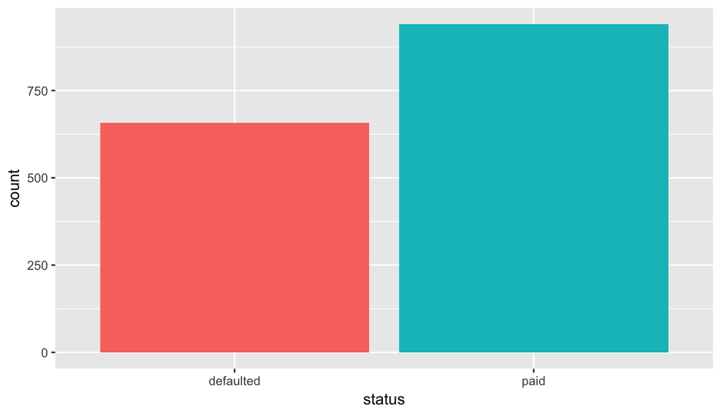

```r
qplot(status, data=df, geom="bar", fill=status, xlab="status") + theme(legend.position = "none")
```

## Variable: sector

The figure below shows the number of loans in each sector, coloured by the loan’s `status`.

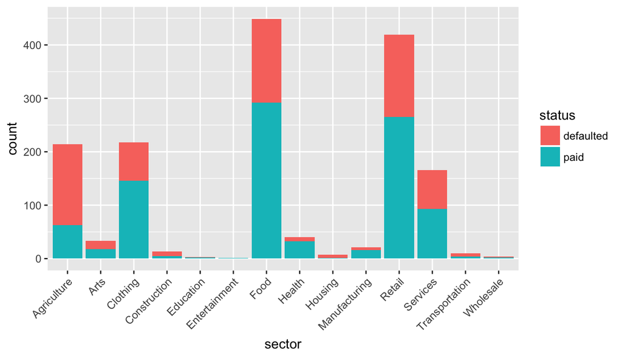

```r
qplot(sector, data=df, geom="bar", fill=status, xlab="sector")+
  theme(axis.text.x = element_text(angle = 45, hjust = 1))
```

## Variable: country

Below is the same for the `country` variable.

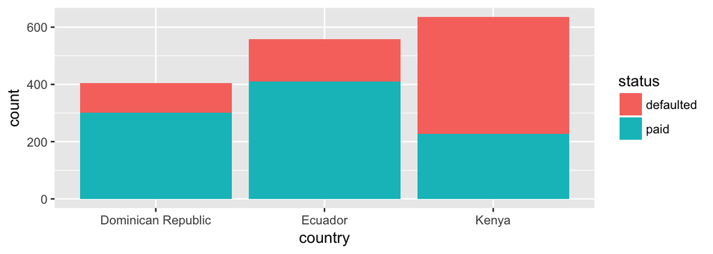

```r
qplot(country, data=df, geom="bar", fill=status)
```

## Variable: gender

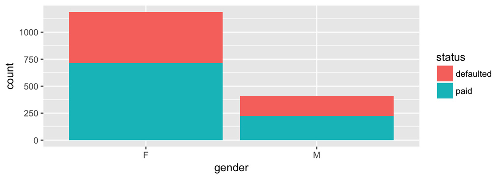

```r
qplot(gender, data=df, geom="bar", fill=status)
```

## Variable: nonpayment

The nonpayment variable captures who is liable if a loan defaults: the lender, or the partner.

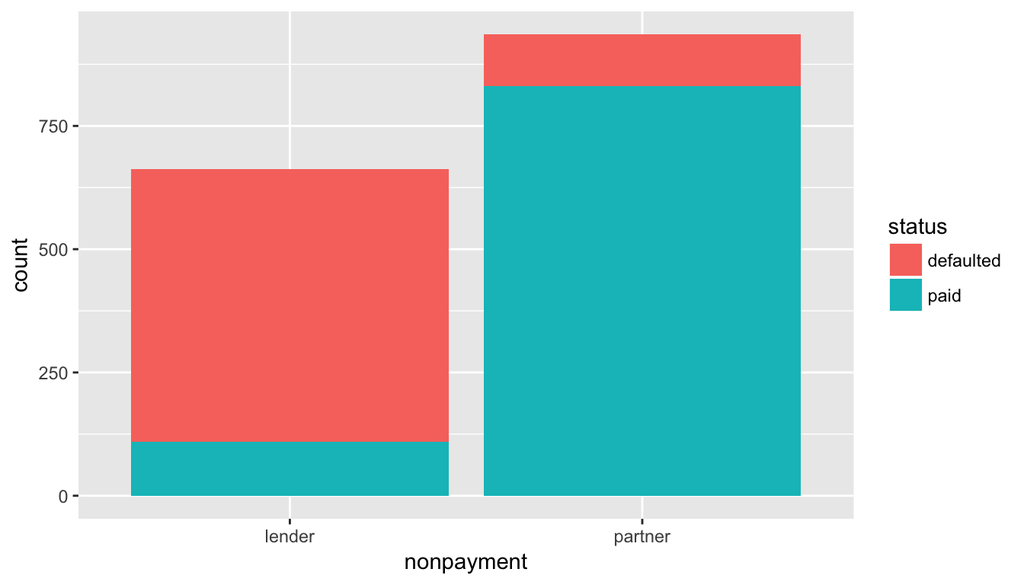

```r
qplot(nonpayment, data=df, geom="bar", fill=status)
```

## Variable: loan_amount

Unlike the other variables thus far, the `loan_amount` variable is numeric. Below is a density plot, which shows the most popular loan amounts.

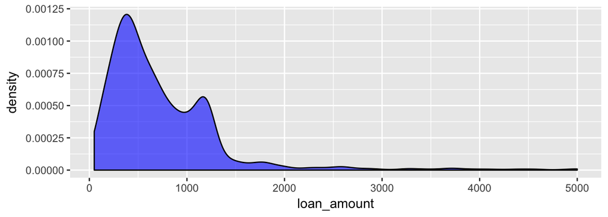

```r
df %>%
  ggplot(aes(loan_amount)) +
  geom_density(fill = "blue", alpha=0.6)
```

Below are separate density curves for `status=defaulted` and `status=paid`.

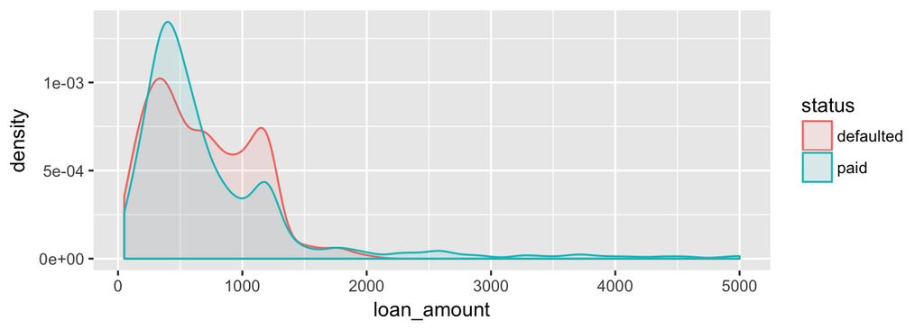

```r
df %>%
  ggplot(aes(loan_amount, colour=status, fill=status)) +
  geom_density(alpha=0.1)
```

Below is a filled density plot:

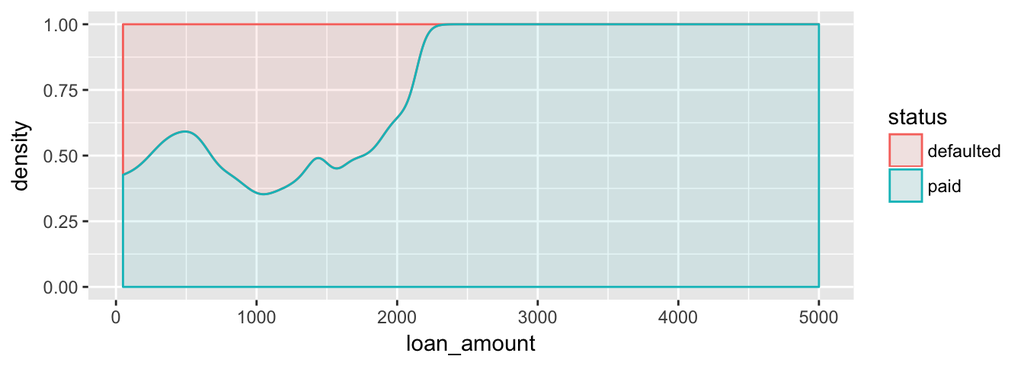

```r
df %>%
  ggplot(aes(loan_amount, colour=status, fill=status)) +
  geom_density(alpha=0.1, position="fill")
```

```r
df$loan_amount.cut = cut(df$loan_amount, breaks=c(0, 300, 600, 900, 1500))
addmargins(table(df$loan_amount.cut, df$status, dnn=c("loan_amount.cut", "status")))
```

```
##                status
## loan_amount.cut defaulted paid  Sum
##   (0,300]             163  193  356
##   (300,600]           163  358  521
##   (600,900]           133  149  282
##   (900,1.5e+03]       182  162  344
##   Sum                 641  862 1503
```

## Variable: en

The `en` variable is raw English text, and there’s lots of ways to look at it.

### Length

The figure below is a density plot of the length (number of characters/letters).

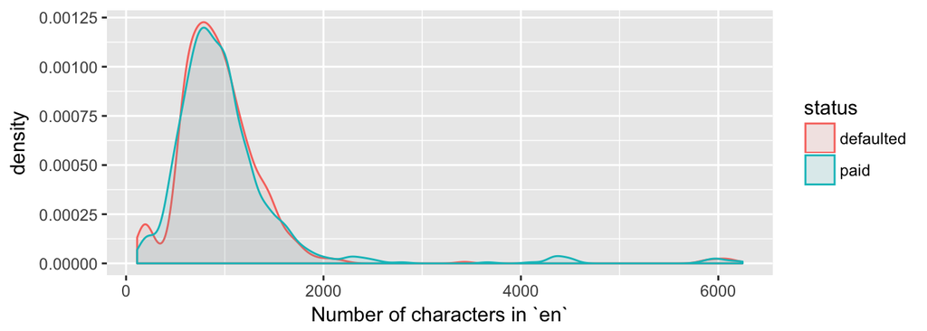

```r
df %>%
  mutate(en_length = nchar(en)) %>%
  ggplot(aes(en_length, colour=status, fill=status)) +
  geom_density(alpha=0.1) +
  labs(x = "Number of characters in `en`")
```

### Top Words

The table below shows the top (i.e, most frequently occuring) words.

```r
text_df %>% group_by(word) %>%
  summarize(count=n()) %>%
  mutate(freq = count / sum(count)) %>%
  arrange(desc(count)) %>%
  top_n(20)
```

```
## # A tibble: 20 × 3
##         word count        freq
##        <chr> <int>       <dbl>
## 1   children  1719 0.015396604
## 2     school   967 0.008661149
## 3        buy   965 0.008643236
## 4      sells   811 0.007263901
## 5     family   739 0.006619017
## 6   products   715 0.006404056
## 7    husband   654 0.005857696
## 8       home   607 0.005436730
## 9     income   602 0.005391946
## 10   selling   599 0.005365076
## 11   married   591 0.005293422
## 12 community   556 0.004979937
## 13  purchase   537 0.004809759
## 14   started   513 0.004594798
## 15     store   503 0.004505231
## 16  increase   464 0.004155919
## 17   clients   449 0.004021568
## 18     house   439 0.003932001
## 19      sell   439 0.003932001
## 20  clothing   437 0.003914087
```

### Most Biased Words

The plots below show which words are most biased towards being `paid` or `defaulted`, using the log odds ratio metric.

```r
status_words_count = text_df %>% group_by(status, word) %>%
  summarize(count=n()) %>%
  arrange(desc(count))

log_ratios = status_words_count %>%
  spread (status, count) %>%
  select(-`<NA>`) %>%
  mutate(defaulted = ifelse(is.na(defaulted), 0, defaulted)) %>%
  mutate(paid = ifelse(is.na(paid), 0, paid)) %>%
  mutate(total=defaulted+paid) %>%
  mutate(log_ratio = log2(paid/defaulted))
```

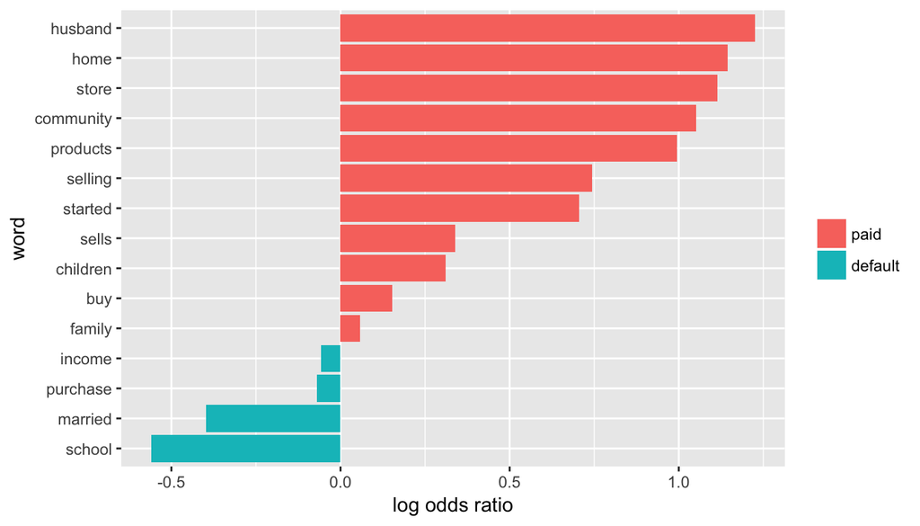

```r
log_ratios %>%
  filter(total > 500) %>%
  group_by(log_ratio < 0) %>%
  top_n(15, abs(log_ratio)) %>%
  ungroup() %>%
  mutate(word = reorder(word, log_ratio)) %>%
  ggplot(aes(word, log_ratio, fill = log_ratio < 0)) +
  geom_col() +
  coord_flip() +
  ylab("log odds ratio") +
  scale_fill_discrete(name = "", labels = c("paid", "default"))
```

Below are tabular versions of the same data above, starting with the words that are biased towards `paid`:

```r
log_ratios %>%
  filter(total > 500) %>%
  arrange(desc(log_ratio)) %>%
  top_n(17)
```

```
## # A tibble: 15 × 5
##         word defaulted  paid total   log_ratio
##        <chr>     <dbl> <dbl> <dbl>       <dbl>
## 1    husband       196   458   654  1.22449394
## 2       home       189   418   607  1.14511671
## 3      store       159   344   503  1.11338180
## 4  community       181   375   556  1.05090090
## 5   products       239   476   715  0.99395096
## 6    selling       224   375   599  0.74339186
## 7    started       195   318   513  0.70555264
## 8      sells       358   453   811  0.33955146
## 9   children       767   952  1719  0.31173500
## 10       buy       457   508   965  0.15263433
## 11    family       362   377   739  0.05857483
## 12    income       307   295   602 -0.05752370
## 13  purchase       275   262   537 -0.06986481
## 14   married       336   255   591 -0.39796399
## 15    school       576   391   967 -0.55890020
```

And those that are biased towards `default`:

```r
log_ratios %>%
  filter(total > 500) %>%
  arrange((log_ratio)) %>%
  top_n(-20)
```

```
## # A tibble: 15 × 5
##         word defaulted  paid total   log_ratio
##        <chr>     <dbl> <dbl> <dbl>       <dbl>
## 1     school       576   391   967 -0.55890020
## 2    married       336   255   591 -0.39796399
## 3   purchase       275   262   537 -0.06986481
## 4     income       307   295   602 -0.05752370
## 5     family       362   377   739  0.05857483
## 6        buy       457   508   965  0.15263433
## 7   children       767   952  1719  0.31173500
## 8      sells       358   453   811  0.33955146
## 9    started       195   318   513  0.70555264
## 10   selling       224   375   599  0.74339186
## 11  products       239   476   715  0.99395096
## 12 community       181   375   556  1.05090090
## 13     store       159   344   503  1.11338180
## 14      home       189   418   607  1.14511671
## 15   husband       196   458   654  1.22449394
```

Let’s use the TF-IDF metric to see which words are the most “important”:

```r
book_words <- text_df %>%
  select(-status) %>%
  count(id, word, sort = TRUE) %>%
  ungroup()

book_words %>% arrange(desc(n))

total_words <- book_words %>%
  group_by(id) %>%
  summarize(total = sum(n))
total_words %>% arrange(desc(total))

book_words <- left_join(book_words, total_words)

freq_by_rank <- book_words %>%
  group_by(id) %>%
  mutate(rank = row_number(),
         `term frequency` = n/total)
book_words_tfidf <- book_words %>%
  bind_tf_idf(word, id, n)

book_words_tfidf %>%
  arrange(desc(tf_idf))
```

[output not shown]

## LDA Topics

Next, we used a techinque called Latent Dirichlet Allocation (LDA) to automatically extract high-level topics from the documents. We told LDA to extract the `12` most important topics; LDA will also tell us which topics are in which documents. For example, a document might have 50% of its words come from topic 1, 25% of its words come from topic 5, and the remaining 25% of its words come from topic 12.

### LDA Top Terms Per Topic

This figure shows the top terms (words) in each of the 12 discovered topic.

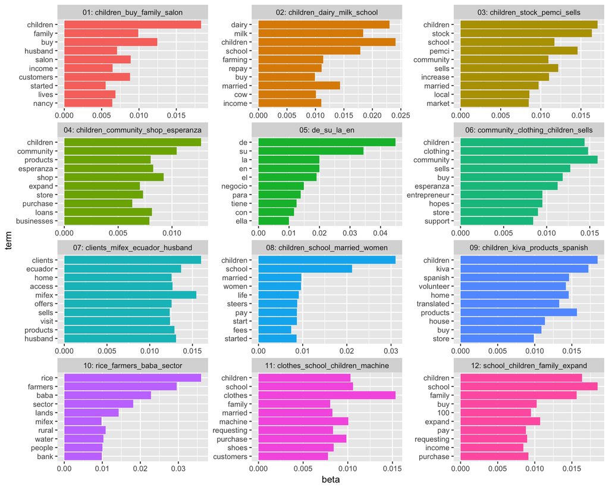

```r
ap_top_terms <- lda_beta %>%
  group_by(topic) %>%
  top_n(10, beta) %>%
  ungroup() %>%
  arrange(topic, -beta)

ap_top_terms %>%
  mutate(term = reorder(term, beta)) %>%
  left_join(tn, by=c("topic" = "id")) %>%
  ggplot(aes(term, beta, fill = factor(topic))) +
  geom_col(show.legend = FALSE) +
  facet_wrap(~ topic_name, scales = "free", ncol=3) +
  coord_flip()
```

### Documents per LDA Topic

The figure below shows the number of documents that contain each topic (i.e., more than 5%), coloured by `status`.

```r
topic_totals = lda_gamma %>%
  left_join(df, by=c("document" = "id")) %>%
  select(c(-en)) %>%
  filter(gamma >= 0.05) %>%
  group_by(topic, status) %>%
  summarize(count=n()) %>%
  spread(status, count) %>%
  mutate(total = defaulted + paid) %>%
  left_join(tn, by=c("topic" = "id")) %>%
  select(topic, topic_name, everything())
```

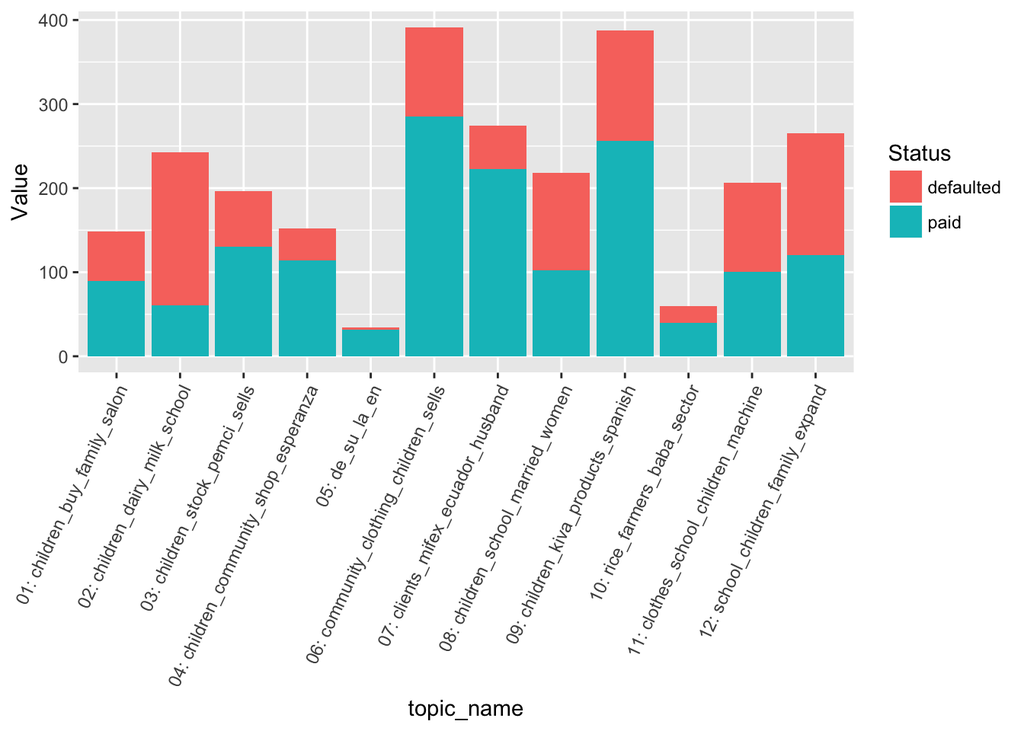

```r
tmp_gathered = topic_totals %>%
  select(topic, topic_name, defaulted, paid) %>%
  gather(Status, Value, defaulted, paid)

ggplot(tmp_gathered, aes(x=topic_name, y=Value, fill=Status)) +
  geom_bar(stat="identity") +
  theme(axis.text.x = element_text(angle = 65, hjust = 1))
```

# Building a Classifier Model

Now that we have explored the data, it’s time to dive deeper. Which variable(s) are the biggest predictors of `status`? This is where classifier models shine. They can tell us exactly how all the variables relate to each other, and which are most important.

A decision tree is a popular classifier model in analytics. Here, the decision tree is automatically created by a machine learning algorithm as it learns simple decision rules from the data. These automatically-learned rules can then be used to both understand the variables and to predict future data. A big advantage of decision trees over other classifier models is that they are relatively simple for humans to understand and interpret.

A decision tree consists of nodes. Each node splits the data according to a rule. A rule is based on a variable in the data. For example, a rule might be “Age greater than 30.” In this case, the node splits the data by the age variable; those passengers that satisfy the rule (i.e., are greater than 30) follow the left path out of the node; the rest follow the right path out of the node. In this way, paths from the root node down to leaf nodes are created, describing the fate of certain types of passengers.

A decision tree path always starts with a root node (node number 1), which contains the most important splitting rule. Each subsequent node contains the next most important rule. After the decision tree is automatically created by the machine learning algorithm, one can use the decision tree to classify an individual by simply following a path: start at the root node and apply each rule to follow the appropriate path until you hit an end.

When creating a decision tree from data, the analyst can specify the number of nodes for the machine learning algorithm to create. More nodes leads to a more accurate model, at the cost of a more complicated and harder-to-interpret model. Likewise, fewer nodes usually leads to a less accurate model, but the model is easier to understand and interpret.

## A Prediction Model without the Text

First, as a baseline, we trained a decision tree classifier model without using any of the text or topics. Below is a graphical depiction of the model after it has been trained:

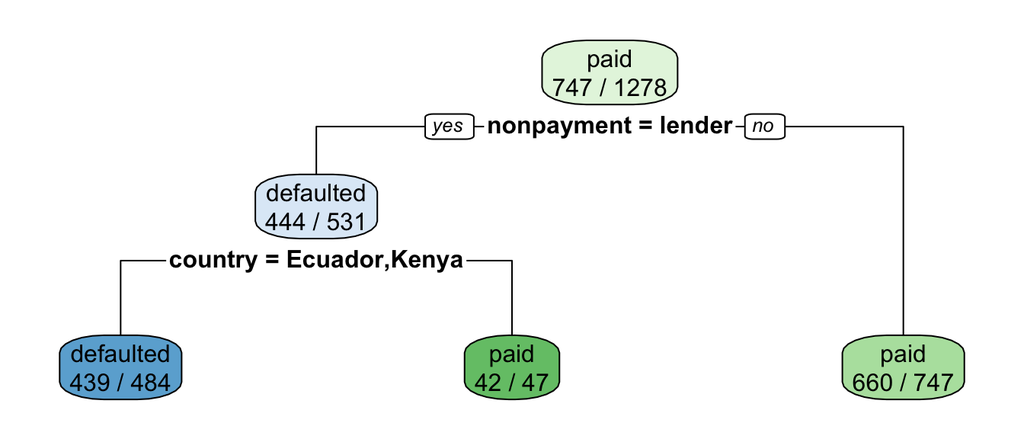

```r
set.seed(123)
# Don't want to use either of these for prediction, and the - sign doesn't work
# with rpart forumulas.
df_notext = subset(df_new, select=c(status, sector, country, gender, loan_amount, nonpayment))

# Split the data into training and testing.
train_notext <- sample_frac(df_notext, 0.8)
test_notext <- setdiff(df_notext, train_notext)


# Let's train the model.
form = as.formula(status ~ .)
tree <- rpart(form, train_notext, method="class")
rpart.plot(tree, extra=2)
```

To measure the prediction performance, we used some never-before-seen data (called *testing data*). We gave the testing data to the classifier, asked it to make a prediction (i.e., whether the borrower will pay or not), and then compared it to the true answer.

The following table summarizes the predictions of the classifier.

```r
predicted = predict(tree, test_notext, type="class")
actual = test_notext$status
preds = data.frame((table(predicted, actual))) %>%
  spread(actual, Freq) %>%
  mutate(total = defaulted + paid) %>%
  select(predicted, total, everything())

preds
```

```
##   predicted total defaulted paid
## 1 defaulted    44        33   11
## 2      paid    75         7   68
```

Below is the accuracy and other metrics of the classifier on the testing data.

```r
print(sprintf("Accuracy:    %.3f", Accuracy(y_true=actual, y_pred=predicted)))
```

```
## [1] "Accuracy:    0.849"
```

```r
print(sprintf("Precision:   %.3f", Precision(y_true=actual, y_pred=predicted)))
```

```
## [1] "Precision:   0.750"
```

```r
print(sprintf("Recall:      %.3f", Recall(y_true=actual, y_pred=predicted)))
```

```
## [1] "Recall:      0.825"
```

```r
print(sprintf("F1 Score:    %.3f", F1_Score(predicted, actual)))
```

```
## [1] "F1 Score:    0.786"
```

```r
print(sprintf("Sensitivity: %.3f", Sensitivity(y_true=actual, y_pred=predicted)))
```

```
## [1] "Sensitivity: 0.825"
```

```r
print(sprintf("Specificity: %.3f", Specificity(y_true=predicted, y_pred=actual)))
```

```
## [1] "Specificity: 0.907"
```

## A Prediction Model with the Text

We then built the same kind of decision tree classifier model as before, except now, we included the LDA topics, which were built from the text. (Note: there are many *other* textual features we could include in this model: individual words, clusters, etc. However, we kept it simple for now.) Below is the result.

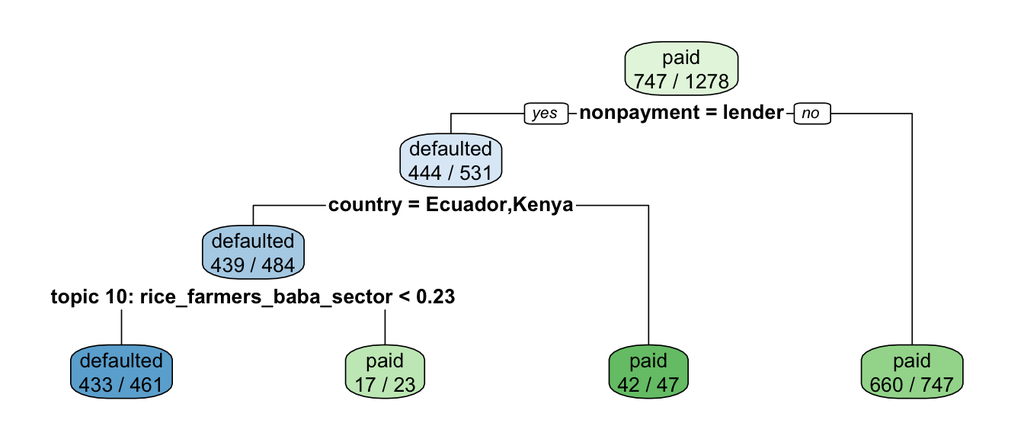

```r
set.seed(123)
# Don't want to use either of these for prediction, and the - sign doesn't work
# with rpart forumulas.
df_text = subset(df_new, select=c(-id, -en))

# Split the data into training and testing.
train_text <- sample_frac(df_text, 0.8)
test_text <- setdiff(df_text, train_text)


# Let's create the model.
form = as.formula(status ~ .)
tree <- rpart(form, train_text, method="class")
rpart.plot(tree, extra=2)
```

Below is a summary of its predictions:

```r
predicted = predict(tree, test_text, type="class")
actual = test_text$status
preds.text = data.frame((table(predicted, actual))) %>%
  spread(actual, Freq) %>%
  mutate(total = defaulted + paid) %>%
  select(predicted, total, everything())


preds.text
```

```
##   predicted total defaulted paid
## 1 defaulted   118       106   12
## 2      paid   178        21  157
```

Metrics:

```r
print(sprintf("Accuracy:    %.3f", Accuracy(y_true=actual, y_pred=predicted)))
```

```
## [1] "Accuracy:    0.889"
```

```r
print(sprintf("Precision:   %.3f", Precision(y_true=actual, y_pred=predicted)))
```

```
## [1] "Precision:   0.898"
```

```r
print(sprintf("Recall:      %.3f", Recall(y_true=actual, y_pred=predicted)))
```

```
## [1] "Recall:      0.835"
```

```r
print(sprintf("F1 Score:    %.3f", F1_Score(predicted, actual)))
```

```
## [1] "F1 Score:    0.865"
```

```r
print(sprintf("Sensitivity: %.3f", Sensitivity(y_true=actual, y_pred=predicted)))
```

```
## [1] "Sensitivity: 0.835"
```

```r
print(sprintf("Specificity: %.3f", Specificity(y_true=predicted, y_pred=actual)))
```

```
## [1] "Specificity: 0.882"
```

# Appendix: Further Reading

- [Kiva.org](https://www.kiva.org/). Kiva’s homepage.
- [Build.Kiva](http://build.kiva.org/). Kiva data dumps and data description.